# IODS course project

__* We then would like to see if the fit is even better, if we use de model allowing also for a group and time interaction.*__

```r
#Performing an ANOVA test on the two models
anova(BPRS_ref2, BPRS_ref1)
```

```
## Data: BPRSL
## Models:
## BPRS_ref1: bprs ~ week + treatment + (week | subject)
## BPRS_ref2: bprs ~ week * treatment + (week | subject)
##           npar    AIC    BIC  logLik deviance  Chisq Df Pr(>Chisq)
## BPRS_ref1    7 2745.4 2772.6 -1365.7   2731.4
## BPRS_ref2    8 2744.3 2775.4 -1364.1   2728.3 3.1712  1    0.07495 .
## ---
## Signif. codes:  0 '***' 0.001 '**' 0.01 '*' 0.05 '.' 0.1 ' ' 1
```

While the Chisq p-value is rather low it is not significant and we can’t conclude that the third model would fit the data better than the second one.

*We continue with the second (BPRS_ref1) model now and plot the fit against the real data to get a final hint of how well the fit actually is.*

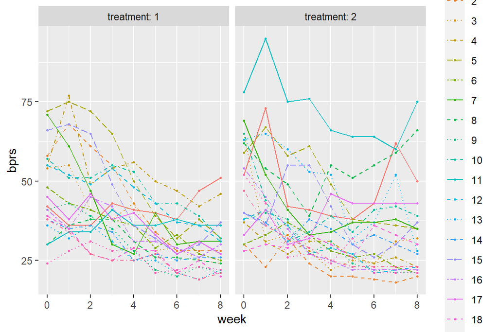

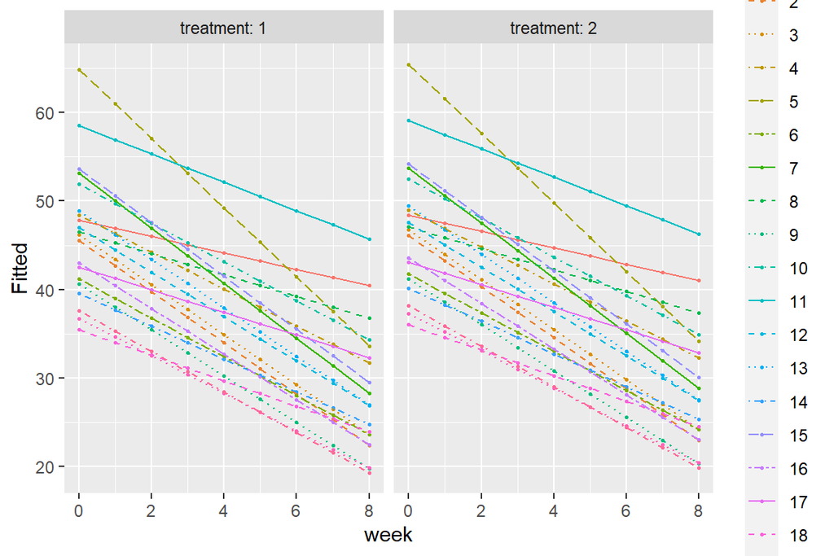

```r
#Drawing the plot of BPRS with the observed bprs values
g_obs <- ggplot(BPRSL, aes(x = week, y = bprs, linetype = subject, col = subject)) +
  geom_point(size = 0.5) +
  geom_line() +
  scale_linetype_manual(values = rep(1:10, times=4)) +
  facet_grid(. ~ treatment, labeller = label_both) +
  scale_y_continuous(limits = c(min(BPRSL$bprs), max(BPRSL$bprs)))

#Creating a vector of the fitted values
Fitted <- fitted(BPRS_ref1)

#Creating a new column fitted to BPRS
BPRSL <- BPRSL %>% mutate(Fitted)


#Drawing the plot of BPRSL with the Fitted values of bprs
g_fit <- ggplot(BPRSL, aes(x = week, y = Fitted, linetype = subject, col = subject)) +
  geom_point(size = 0.5) +
  geom_line() +
  scale_linetype_manual(values = rep(1:10, times=4)) +
  facet_grid(. ~ treatment, labeller = label_both) +
  scale_y_continuous(limits = c(min(BPRSL$Fitted), max(BPRSL$Fitted)))

g_obs; g_fit
```

We can see from the graphs that the fitted model seem to be rather similar to the original data, but with a smaller variance from the mid-line. However a linear model might not be the best to fit to this data set where we clearly see from the raw data that the scoring change is non-linear and that the slope of the graphs is changing direction through out the weeks.

If we interpret the output from the model one would say that the scoring i decreasing with time and that the treatment approaches is equally good, however the model misses the temporal differences in affect at different time points, that the slope is reaching a minimum at week 6 and that some data points is actually changing direction after that. It would be interesting to see data for later time points also to see the long-term affect.